# Data Quality Analysis

# Missing data in the annual ACS file

In this document we highlight missing data in the ACS microdata and we explain how we address these problems in our subsequent analysis. We note that the ACS may automatically impute some missing values included in the original survey results. These results are the missing values as given in the annual microdata.

```r
# load libraries and set dirs ------------------------------------------------------------------------------------------
library(tidyverse)

person_data = read_rds('../../01_ProcessedData/missing-acs-person-data.rds')
household_data = read_rds('../../01_ProcessedData/missing-acs-household-data.rds')
```

## Person File

We first summarize the total number of missing observations for each variable contained in the dataset.

```r
person_data %>%
  mutate(across(contains('missing'), ~.x/sample)) %>%
  ungroup() %>%
  select(-sample, -state, -cpuma, -year) %>%
  ungroup() %>%
  summarize_all(mean) %>%
  sort(decreasing = TRUE) %>%
  t()
```

```
##                            [,1]
## missing_student      0.88578953
## missing_inc_pov      0.04187393
## missing_age_all      0.00000000
## missing_citizenship  0.00000000
## missing_foreign_born 0.00000000
## missing_employment   0.00000000
## missing_age_sample   0.00000000
## missing_disability   0.00000000
## missing_hispanic     0.00000000
## missing_hins1        0.00000000
## missing_hins2        0.00000000
## missing_hins3        0.00000000
## missing_hins4        0.00000000
## missing_hins5        0.00000000
## missing_hins6        0.00000000
## missing_hins7        0.00000000
## missing_educ         0.00000000
## missing_race         0.00000000
## missing_sex          0.00000000
## missing_married      0.00000000
```

We see that in the person file the only variable with missing values are `student`, and `inc_pov`. Student is 88.6 percent missing on average. Our student variable we include simply summarizes the data to be one if the person is a student and zero otherwise. We should therefore interpret this variable carefully in that the reference category is both missing values, who might be students, and non-students.

We now take a closer look at `inv_pov`, and examine the distribution of missingness (note that the analysis is at the CPUMA-year level, so CPUMAs may appear multiple times):

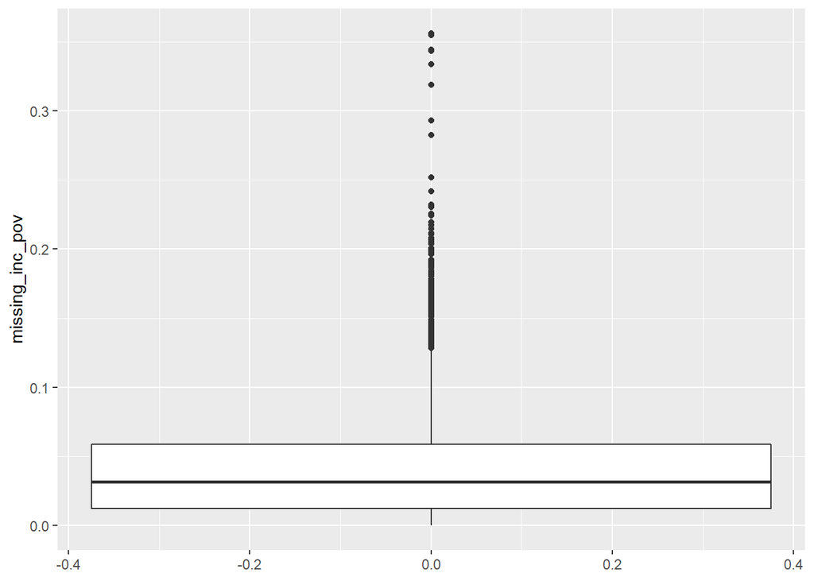

```r
person_data %>%
  select(cpuma, state, year, missing_inc_pov, sample) %>%
  mutate(missing_inc_pov = missing_inc_pov/sample) %>%
  ggplot(aes(y = missing_inc_pov)) +
  geom_boxplot()
```

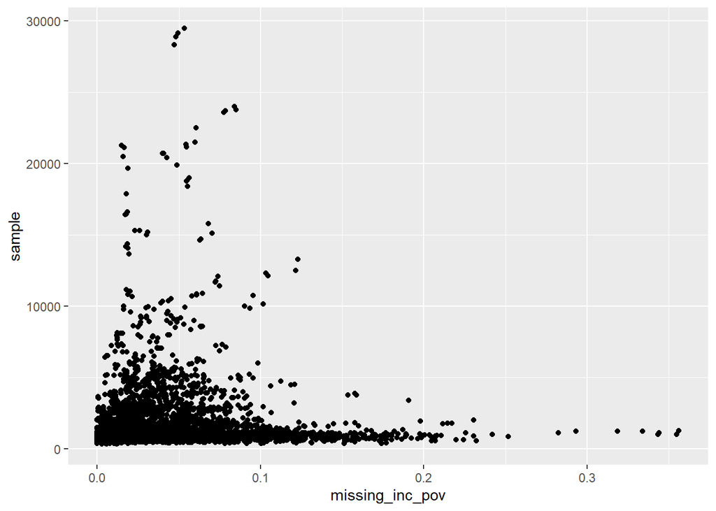

```r
person_data %>%
  select(cpuma, state, year, missing_inc_pov, sample) %>%
  mutate(missing_inc_pov = missing_inc_pov/sample) %>%
  select(missing_inc_pov, sample) %>%
  ggplot(aes(x = missing_inc_pov, y = sample)) +
  geom_point()
```

We see that only CPUMAs with smaller overall samples had such high percentages of missing data.

```r
person_data %>%
  select(cpuma, state, year, missing_inc_pov, sample) %>%
  mutate(missing_inc_pov = missing_inc_pov/sample) %>%
  arrange(-missing_inc_pov) %>%
  filter(missing_inc_pov > .10) %>%
  ungroup() %>%
  select(state) %>%
  table() %>%
  sort()
```

```
## .
## 31 32 47 49 13 27 45 01 19 37 02 05 44 53 04 15 34 51 21 26 17 18 22 29 40 25
##  1  1  1  1  2  2  2  3  3  3  4  4  4  4  5  5  5  5  6  7  8  8  8  8 10 13
## 24 39 09 12 48 42 06 36
## 14 14 15 17 28 34 44 54
```

## Household File

We now consider missing data in the household file. The only variable we use for household covariates is number of children. Note that we do not link this file to the person dataset (using the SERIALNO variable), but separately aggregate these numbers.

We first examine the distribution of missing data for number of children, again at the CPUMA-year level (where the individual-level data is at the household-level):

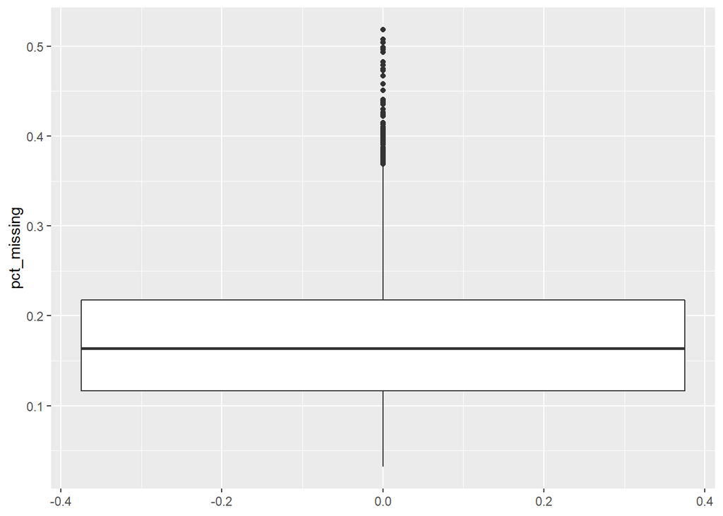

```r
household_missing = household_data %>%
  select(cpuma, state, year, missing_noc, sample) %>%
  mutate(pct_missing = missing_noc/sample)

household_missing %>%
  ggplot(aes(y = pct_missing)) +
  geom_boxplot()
```

We see that the percentage of observations with missing children can be quite high with substantial outliers. Overall we get on average 17.4 percent missing values with a median of 16.4 percent and a maximum of 51.85 percent.

```r
summary(household_missing$pct_missing)
```

```
##    Min. 1st Qu.  Median    Mean 3rd Qu.    Max.
## 0.03221 0.11662 0.16404 0.17400 0.21757 0.51848
```

```r
household_missing %>%
  filter(pct_missing > 0.3) %>%
  ungroup() %>%
  select(state) %>%
  table() %>%
  sort()
```

```
## .
## 39 53 12 50 55 10 29 49 51 21 22 33 37 40 44 18 45 23 24 35 02 34 04 09 25 26
##  1  1  2  2  2  3  3  3  3  4  4  4  4  4  4  5  6  8  8  8 11 11 12 12 13 17
## 48 06 42 36
## 19 26 35 50
```